# Report for Reproducible Research - Assessment1

Roberto Lo Prejato

25 ottobre 2018

In thi assignment I make use of data from a personal activity monitoring device. This device collects data at 5 minute intervals through out the day. The data consists of two months of data from an anonymous individual collected during the months of October and November, 2012 and include the number of steps taken in 5 minute intervals each day.

```r
library(dplyr)
library(ggplot2)
library(gridExtra)
library(lubridate)
```

## Loading and preprocessing the data

First of all I need to load the file.csv with data and store it in a variable names “activity”"

```r
if(!file.exists('activity.csv')){
    unzip('activity.zip')
}
activity <- read.csv("activity.csv")
```

In the following histogram we can see the total numer of steps taken per day

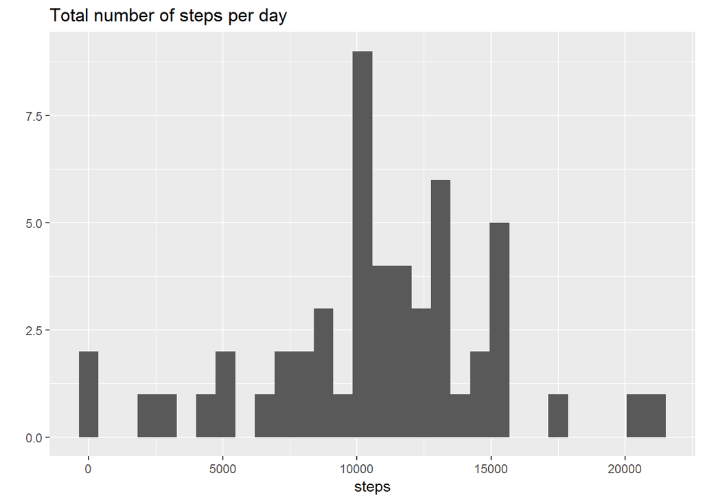

```r
act_na <- filter(activity, !is.na(steps))
activity_sum <- act_na %>% group_by(date) %>% summarize(st_tot= sum(steps))
qplot(st_tot, data=activity_sum, bins=30, main="Total number of steps per day", xlab="steps")
```

```r
mean_steps <- round(mean(activity_sum$st_tot), digits = 2)
median_steps <- median(activity_sum$st_tot)
```

Considering the 5-minute interval (x-axis) and the average number of steps taken, averaged across all days (y-axis) we can see the average daily activity pattern.

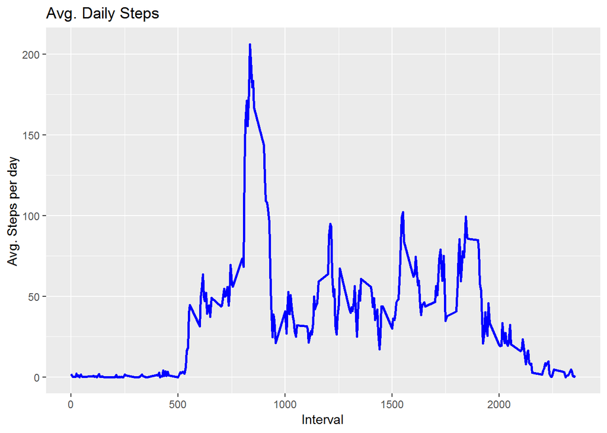

```r
activity_interval <- act_na %>% group_by(interval) %>% summarize(st_mean= mean(steps))
interval_max <- activity_interval%>%filter(st_mean == max(st_mean))%>%select(1)
p1 <- ggplot(activity_interval, aes(x = interval , y = st_mean))
p1+geom_line(color="blue", size=1) + labs(title = "Avg. Daily Steps", x = "Interval", y = "Avg. Steps per day")
```

The 5-minute interval with most steps on average across all the days is 835.

## Imputing missing values

```r
row_na <- nrow(activity)-nrow(act_na)
row_na <- nrow(activity)-nrow(act_na)
x<-activity %>% group_by(date) %>% summarize(tot_steps = sum(steps)) %>% filter(is.na(tot_steps))
day_na <- nrow(x)
```

In this database there are 2304 row with null value as steps and 8 dayes with no data for steps. Now we will fill the NA value for 2304 row with the median of steps fot the specific 5-minutes interval so we can create a new database without null value in steps column

```r
data_fill <- act_na %>% group_by(interval) %>% summarize(st_median = median(steps))
act_fill <- activity %>% filter(is.na(steps)) %>% merge(data_fill) %>% select(-steps) %>% rename(steps =st_median)
#create a new db filling NA value
activity_fill <- bind_rows(act_fill,act_na)
```

With this new dataset we can make again the histogram with the the total numer of steps taken per day and chack if somethings will change.

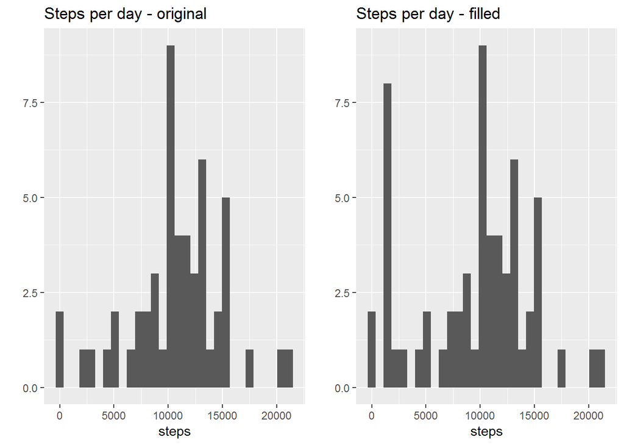

```r
activity_sum2 <- activity_fill %>% group_by(date) %>% summarize(st_tot= sum(steps))
require(gridExtra)
plot1<-qplot(st_tot, data=activity_sum, bins=30, main="Steps per day - original", xlab="steps")
plot2<-qplot(st_tot, data=activity_sum2, bins=30, main="Steps per day - filled", xlab="steps")
grid.arrange(plot1, plot2, ncol=2)
```

```r
mean_steps2 <- round(mean(activity_sum2$st_tot), digits = 2)
median_steps2 <- median(activity_sum2$st_tot)
```

## Are there differences in activity patterns between weekdays and weekends?

We use the dataset with the filled-in missing values for this part. we want to see if there is a different behavior between the weekdays the weekend. For this reason we create a new factor variable in the dataset with two levels (“Weekday” and “Weekend”) indicating whether a given date is a weekday or weekend day.

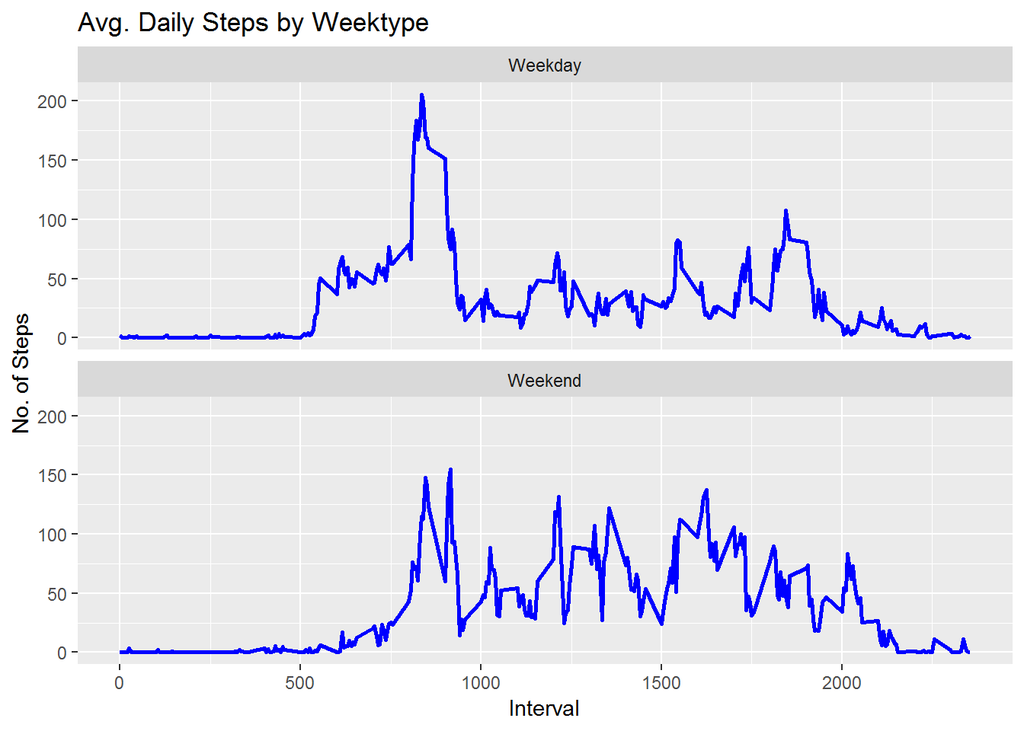

```r
activity_fill$dayofweek <- weekdays(as.Date(activity_fill$date))
activity_fill$weekend <-as.factor(activity_fill$dayofweek=="sabato"|activity_fill$dayofweek=="domenica")
levels(activity_fill$weekend) <- c("Weekday", "Weekend")
act_week <- activity_fill %>% group_by(interval, weekend) %>% summarize(st_mean= mean(steps))
ggplot(act_week, aes(x = interval , y = st_mean)) + geom_line(color="blue", size=1) + labs(title = "Avg. Daily Steps by Weektype", x = "Interval", y = "No. of Steps") + facet_wrap(~weekend , ncol = 1, nrow=2)
```

From the graph we can see that during the weekend the number of steps is higher in the middle of the day